# fema_prework

## Exploratory Data Analysis: FEMA disaster declarations: Disaster Declarations Summaries v2

### Author: Sampson Mao

### 1. Data Exploration

```python
import pandas as pd
import numpy as np
import seaborn as sns
import missingno as msno
import matplotlib.pyplot as plt
import matplotlib.colors as mcolors
import seaborn as sns
import geopandas as gpd
from shapely.geometry import Polygon
import plotly.express as px

pd.set_option('display.max_columns', 500)
pd.set_option('display.max_rows', 500)
```

```python
df = pd.read_csv('DisasterDeclarationsSummaries.csv')
df.head()
```

|  | femaDeclarationString | disasterNumber | state | declarationType | declarationDate | fyDeclared | incidentType | declarationTitle | ihProgramDeclared | iaProgramDeclared | paProgramDeclared | hmProgramDeclared | incidentBeginDate | incidentEndDate | disasterCloseoutDate | tribalRequest | fipsStateCode | fipsCountyCode | placeCode | designatedArea | declarationRequestNumber | lastIAFilingDate | lastRefresh | hash | id |
| --- | --- | --- | --- | --- | --- | --- | --- | --- | --- | --- | --- | --- | --- | --- | --- | --- | --- | --- | --- | --- | --- | --- | --- | --- | --- |
| 0 | FM-5464-RI | 5464 | RI | FM | 2023-04-14T00:00:00.000Z | 2023 | Fire | QUEENS RIVER FIRE | 0 | 0 | 1 | 1 | 2023-04-14T00:00:00.000Z | 2023-04-16T00:00:00.000Z | NaN | 0 | 44 | 9 | 99009 | Washington (County)(in (P)MSA 5520,6480) | 23042 | NaN | 2023-05-22T03:41:22.800Z | 1111d4d4a33f8a6e4d383ac5bd0e60b9bf142da0 | 9b9a9d9c-8b03-4049-9b16-a3c0d581556c |
| 1 | FM-5463-KS | 5463 | KS | FM | 2023-04-13T00:00:00.000Z | 2023 | Fire | HADDAM FIRE | 0 | 0 | 1 | 1 | 2023-04-13T00:00:00.000Z | 2023-04-16T00:00:00.000Z | NaN | 0 | 20 | 201 | 99201 | Washington (County) | 23038 | NaN | 2023-05-22T03:41:22.800Z | 78dd55a181f146622eb65835b5d794689d1ea7f2 | 57d936ce-a0d7-412a-9d78-18aee530c146 |
| 2 | DR-4731-CO | 4731 | CO | DR | 2023-08-25T00:00:00.000Z | 2023 | Flood | SEVERE STORMS, FLOODING, AND TORNADOES | 0 | 0 | 1 | 1 | 2023-06-08T00:00:00.000Z | 2023-06-23T00:00:00.000Z | NaN | 0 | 8 | 9 | 99009 | Baca (County) | 23081 | NaN | 2023-10-02T19:21:20.859Z | 44d903d3d79b5295f58aefdd35682a8d3011644d | fe1befa2-d7ac-4400-b430-36bf30ac9a15 |
| 3 | DR-4731-CO | 4731 | CO | DR | 2023-08-25T00:00:00.000Z | 2023 | Flood | SEVERE STORMS, FLOODING, AND TORNADOES | 0 | 0 | 1 | 1 | 2023-06-08T00:00:00.000Z | 2023-06-23T00:00:00.000Z | NaN | 0 | 8 | 61 | 99061 | Kiowa (County) | 23081 | NaN | 2023-10-02T19:21:20.859Z | ecfd4777766336e18a46d1eb231fc25922f8b014 | 880f5941-94fb-4c00-afb8-2f1e32fe1b5b |
| 4 | DR-4731-CO | 4731 | CO | DR | 2023-08-25T00:00:00.000Z | 2023 | Flood | SEVERE STORMS, FLOODING, AND TORNADOES | 0 | 0 | 1 | 1 | 2023-06-08T00:00:00.000Z | 2023-06-23T00:00:00.000Z | NaN | 0 | 8 | 99 | 99099 | Prowers (County) | 23081 | NaN | 2023-10-02T19:21:20.859Z | 90ab966409613986143ee242870748e8d19aa525 | 875a66ca-6234-423a-9e92-3626484e11d6 |

According to the webpage for the dataset, this dataset consists of federally declared disasters, featuring 3 declaration types: Disaster Declaration (DR), Emergency Declaration (EM), Fire Management Assistance Declaration (FM). It also includes declared recovery programs and geographic areas. County information is not available before 1964, and fire mangement records are considered partial due to historical nature of the dataset.

Key columns include `state`, `declarationType`, `declarationDate`, indicating when the disaster declarations were made, the state they were made, and the type of declaration made. We also have columns that informs us of the relevant recovery programs for the disasters. In addition, we have `declarationTitle`, giving the name of the disaster, i.e. Hurricane Katrina, the type of incident `incidentType`, and associated date columns indicating when the disaster began and end.

We can also see that the `femaDeclarationString` is a combination of the `declarationType`, `disasterNumber`, and `state`. This can be redundant depending on the application. For example, predictive modeling. In addition, we have `fipsStateCode`, which is a numeric code uniquely identifying states, so this column is also redundant.

In the first 5 rows, we can tell that this data set has missing data, in `disasterCloseoutDate` and `lastIAFilingDate`.

Digging into the features, there are indeed 3 declaration types, and 25 incident types, including fires, hurricanes, and even toxic substances.

```python
df.declarationType.unique()
```

```
array(['FM', 'DR', 'EM'], dtype=object)
```

```python
df.incidentType.unique()
```

```
array(['Fire', 'Flood', 'Hurricane', 'Severe Storm', 'Winter Storm',
       'Tornado', 'Snowstorm', 'Earthquake', 'Biological',
       'Mud/Landslide', 'Coastal Storm', 'Other', 'Severe Ice Storm',
       'Dam/Levee Break', 'Tropical Storm', 'Tsunami', 'Typhoon',
       'Volcanic Eruption', 'Freezing', 'Toxic Substances', 'Chemical',
       'Terrorist', 'Drought', 'Human Cause', 'Fishing Losses'],
      dtype=object)
```

There are about 65,000 rows and 25 features total in this data set.

```python
df.shape
```

```
(65037, 25)
```

```python
df.dtypes
```

```
femaDeclarationString       object
disasterNumber               int64
state                       object
declarationType             object
declarationDate             object
fyDeclared                   int64
incidentType                object
declarationTitle            object
ihProgramDeclared            int64
iaProgramDeclared            int64
paProgramDeclared            int64
hmProgramDeclared            int64
incidentBeginDate           object
incidentEndDate             object
disasterCloseoutDate        object
tribalRequest                int64
fipsStateCode                int64
fipsCountyCode               int64
placeCode                    int64
designatedArea              object
declarationRequestNumber     int64
lastIAFilingDate            object
lastRefresh                 object
hash                        object
id                          object
dtype: object
```

Pandas does its best to figure out the data types of the data when loading, but it is not able to detect boolean and datetime columns. Dates are in ISO 8601 format, and there are boolean features in the data set. Here, we update the dataframe to reflect this. Of note, the time columns all begin on midnight UTC. While the dates do have a time component, there does not seem to be any entries specific down to the hour, except for `lastRefresh`. This makes sense as paperwork deals mostly in terms of days and months rather than hours.

```python
df = df.astype({
    'declarationDate': 'datetime64[ns, UTC]',
    'ihProgramDeclared': bool,
    'iaProgramDeclared': bool,
    'paProgramDeclared': bool,
    'hmProgramDeclared': bool,
    'incidentBeginDate': 'datetime64[ns, UTC]',
    'incidentEndDate': 'datetime64[ns, UTC]',
    'disasterCloseoutDate': 'datetime64[ns, UTC]',
    'tribalRequest': bool,
    'lastIAFilingDate': 'datetime64[ns, UTC]',
    'lastRefresh': 'datetime64[ns, UTC]'
})
```

```python
df[['declarationDate', 'incidentBeginDate', 'incidentEndDate', 'lastIAFilingDate']].apply(lambda x: x.dt.time).drop_duplicates()
```

|  | declarationDate | incidentBeginDate | incidentEndDate | lastIAFilingDate |
| --- | --- | --- | --- | --- |
| 0 | 00:00:00 | 00:00:00 | 00:00:00 | NaT |
| 6 | 00:00:00 | 00:00:00 | 00:00:00 | 00:00:00 |
| 11 | 00:00:00 | 00:00:00 | NaT | NaT |

The `declarationTitle` had extra whitespaces in the data, so we will use a function to remove extra whitespaces from all columns. 'BLIZZARD OF 96 ' containing an extra space at the end for instance.

```python
df['declarationTitle']
```

```
0                             QUEENS RIVER FIRE
1                                   HADDAM FIRE
2        SEVERE STORMS, FLOODING, AND TORNADOES
3        SEVERE STORMS, FLOODING, AND TORNADOES
4        SEVERE STORMS, FLOODING, AND TORNADOES
                          ...
65032                           BLIZZARD OF 96
65033                           BLIZZARD OF 96
65034                     NORTHRIDGE EARTHQUAKE
65035                     NORTHRIDGE EARTHQUAKE
65036                     NORTHRIDGE EARTHQUAKE
Name: declarationTitle, Length: 65037, dtype: object
```

```python
df = df.apply(lambda x: x.str.strip() if x.dtype == "object" else x)
```

### 2. Data Cleaning

Using the `missingno` package, we can visually see if there are any rows that contain missing data, and which columns they occur in. The data set looks largely complete except dates: `incidentEndDate`, `disasterCloseoutDate`, and `lastIAFilingDate` have missing entries, with `lastIAFilingDate` missing the most.

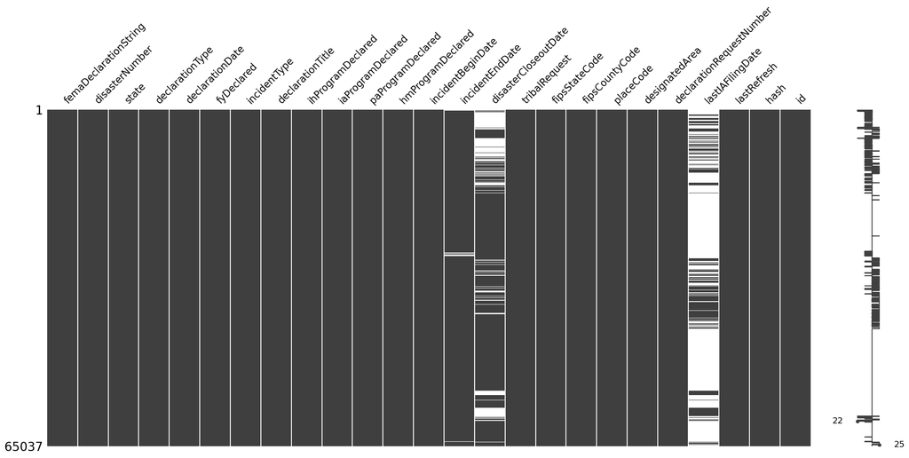

```python
msno.matrix(df)
```

For the `incidentEndDate`, the missingness may be caused by lack of update. In the dataset, there is only one `declarationTitle` that has an end date but was not recorded. There were different declaration dates for this incident but the incident started on the same day. To address the missingness, I will calculate an average incident duration and estimate the end date using the calculation.

```python
# Join table with missing dates and table without missing dates on common columns to find which incidents have a date but not recorded

titles_missing_end_date = df[df['incidentEndDate'].isnull()].declarationTitle.unique()
titles_with_end_dates = df.query("declarationTitle in @titles_missing_end_date").dropna(subset='incidentEndDate')[['declarationTitle', 'incidentBeginDate', 'incidentEndDate']].drop_duplicates()
df.merge(titles_with_end_dates, on=['declarationTitle', 'incidentBeginDate'], how='inner').query("incidentEndDate_x.isnull()")
```

|  | femaDeclarationString | disasterNumber | state | declarationType | declarationDate | fyDeclared | incidentType | declarationTitle | ihProgramDeclared | iaProgramDeclared | paProgramDeclared | hmProgramDeclared | incidentBeginDate | incidentEndDate_x | disasterCloseoutDate | tribalRequest | fipsStateCode | fipsCountyCode | placeCode | designatedArea | declarationRequestNumber | lastIAFilingDate | lastRefresh | hash | id | incidentEndDate_y |
| --- | --- | --- | --- | --- | --- | --- | --- | --- | --- | --- | --- | --- | --- | --- | --- | --- | --- | --- | --- | --- | --- | --- | --- | --- | --- | --- |
| 0 | FM-5413-CA | 5413 | CA | FM | 2021-08-17 00:00:00+00:00 | 2021 | Fire | CALDOR FIRE | False | False | True | True | 2021-08-14 00:00:00+00:00 | NaT | NaT | False | 6 | 17 | 99017 | El Dorado (County) | 21073 | NaT | 2023-05-22 03:41:22.800000+00:00 | 6766ff8f644b233ba059a55454d5af9c2cb90c98 | 975448f7-1bfa-4153-b90a-dda32de7bb6a | 2021-10-21 00:00:00+00:00 |

```python
df.loc[df['femaDeclarationString'] == 'FM-5413-CA', 'incidentEndDate'] = df.query("declarationTitle == 'CALDOR FIRE'").incidentEndDate.dropna().unique()[0]
```

To fill in the end dates, I will calculate the average time for a disaster to "end", and add that time to the `incidentBeginDate`. This will let us obtain a typical `incidentEndDate` for that type of disaster. Below, I calculate the average incident duration `incidentDuration` by `declarationType` and `incidentType`. Grouping by two columns allows the averages to be more granular.

```python
df['incidentDuration'] = df['incidentEndDate'] - df['incidentBeginDate']
average_durations = df.groupby(['declarationType', 'incidentType'])['incidentDuration'].mean().reset_index()
average_durations['days'] = average_durations.incidentDuration.dt.days
```

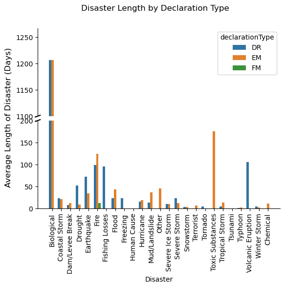

```python
f, (ax_top, ax_bottom) = plt.subplots(ncols=1, nrows=2, sharex=True, gridspec_kw={'hspace':0.05})
sns.barplot(data=average_durations, x='incidentType', y='days', hue='declarationType', ax=ax_top)
sns.barplot(data=average_durations, x='incidentType', y='days', hue='declarationType', ax=ax_bottom)
ax_top.set_ylim(bottom=1100)
ax_bottom.set_ylim(0,200)

sns.despine(ax=ax_bottom)
sns.despine(ax=ax_top, bottom=True)

kwargs = dict(transform=ax_top.transAxes, color='k', clip_on=False)
ax_top.plot((-0.01, 0.01), (-0.01, 0.01), **kwargs)
ax_top.spines.bottom.set_visible(False)
ax_top.tick_params(labeltop=False)
ax_top.set_ylabel('')
ax_top.tick_params(axis='x', which='both', bottom=False,
    top=False,
    labelbottom=False)

kwargs.update(transform=ax_bottom.transAxes)
ax_bottom.plot((-0.01, 0.01), (1 - 0.01, 1 + 0.01), **kwargs)
ax_bottom.set_xticklabels(ax_bottom.get_xticklabels(), rotation=90)
ax_bottom.spines.top.set_visible(False)
ax_bottom.xaxis.tick_bottom()
ax_bottom.set_ylabel('')
ax_bottom.set_xlabel('Disaster')
ax_bottom.legend_.remove()

f.supylabel('Average Length of Disaster (Days)')
f.suptitle('Disaster Length by Declaration Type')
plt.show()
```

```python
def fill_in_end_date(row):
    dec_type = row['declarationType']
    inc_type = row['incidentType']
    if row['incidentEndDate'] is pd.NaT:
        return row['incidentBeginDate'] + average_durations.query("declarationType == @dec_type and incidentType == @inc_type")['incidentDuration'].values[0]
    else:
        return row['incidentEndDate']
```

```python
df['incidentEndDate'] = df.apply(fill_in_end_date, axis=1)
```

`lastIAFilingDate` is only available 1998 and beyond. This column refers to the last date when IA (individual assistance) requests can be filed and only applies if IA has been approved for the disaster. This means anything before 1998 can be classified as `unknown`. For dates after, they can be approved or not approved. Furthermore, 1998 only has 1 date, which is 10/24/1998. The approvial for the program is indicated by the column `iaProgramDeclared`. Additionally, based on the website: "Even if “iaProgramDeclared” is blank and "ihProgramDeclared" has a value, the FEMA event was authorized to receive “Individual Assistance.” This is due to a program name change that occurred as result of the Disaster Mitigation Act of 2000, Public Law 106-390 Oct. 30, 2000." This means that both of these columns can tell us whether the lastIAFilingDate' is relevant in a particular row. For some of the data, there is a date but the disaster was not approved for IA. The remaining rows have IA filings that were approved, but no date. For these rows, I will fill them in with the average number of days until the last filing date, similar to before. For this column, I will not find averages per incident type, as some incident types contain no dates.

```python
df.query("fyDeclared == 1998").agg(['min', 'max'])['lastIAFilingDate']
```

```
min   1998-10-24 00:00:00+00:00
max   1998-10-24 00:00:00+00:00
Name: lastIAFilingDate, dtype: datetime64[ns, UTC]
```

```python
# Unknown or denied
def fill_filing_date(row):
    if row['fyDeclared'] < 1998:
        return 'unknown'
    elif row['iaProgramDeclared'] or row['ihProgramDeclared']:
        return row['lastIAFilingDate']
    else:
        return 'denied'
```

```python
# Calculate filing time
df['IAFilingTime'] = df['lastIAFilingDate'] - df['declarationDate']
```

```python
# Impute unknown/denied
df['lastIAFilingDate'] = df.apply(fill_filing_date, axis=1)
```

```python
avg_filing_time = df.query('fyDeclared >= 1998').groupby(['fyDeclared'])['IAFilingTime'].mean().reset_index()
avg_filing_time['days'] = avg_filing_time.IAFilingTime.dt.days
```

Filing time varies by year. 2020 had a high time due to covid.

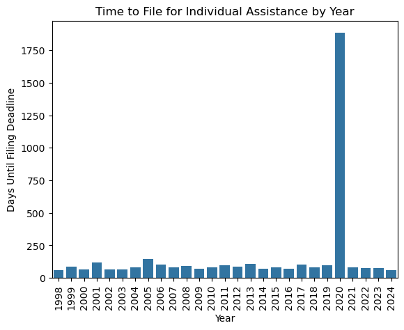

```python
g = sns.barplot(avg_filing_time, x='fyDeclared', y='days')
g.set_xticklabels(g.get_xticklabels(), rotation=90)
g.set_title("Time to File for Individual Assistance by Year")
g.set_ylabel("Days Until Filing Deadline")
g.set_xlabel("Year")
```

```python
# Fill in dates
def fill_in_filing_date2(row):
    fy = row['fyDeclared']
    if row['lastIAFilingDate'] is pd.NaT:
        return row['declarationDate'] + avg_filing_time.query("fyDeclared == @fy")['IAFilingTime'].values[0]
    else: return row['lastIAFilingDate']
```

```python
df['lastIAFilingDate']= df.apply(fill_in_filing_date2, axis=1)
```

Finally, we have the `disasterCloseoutDate`, the date when financial transactions for all FEMA assistance programs are completed. Here, I will also calculate the average time it takes until a declaration is closed. Below, we can see that the time until close varies depending on the type of disaster, with tropical storms being the shortest and volcanic eruptions being the longest.

```python
df['closeoutTime'] = df['disasterCloseoutDate'] - df['declarationDate']
```

```python
avg_closing_time = df.groupby(['incidentType'])['closeoutTime'].mean().reset_index()
avg_closing_time['days'] = avg_closing_time.closeoutTime.dt.days
```

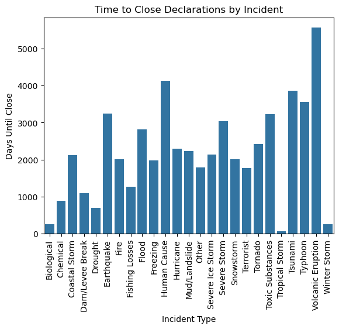

```python
g = sns.barplot(avg_closing_time, x='incidentType', y='days')
g.set_xticklabels(g.get_xticklabels(), rotation=90)
g.set_title("Time to Close Declarations by Incident")
g.set_ylabel("Days Until Close")
g.set_xlabel("Incident Type")
```

```python
def fill_in_closeout_date(row):
    inc_type = row['incidentType']
    if row['disasterCloseoutDate'] is pd.NaT:
        return row['declarationDate'] + avg_closing_time.query("incidentType == @inc_type")['closeoutTime'].values[0]
    else:
        return row['disasterCloseoutDate']
```

```python
df['disasterCloseoutDate'] = df.apply(fill_in_closeout_date, axis=1)
```

### 3. Data Visualization

#### 3.1 Number of Disasters Per year

```python
num_disasters_per_year = df.groupby('fyDeclared').count()['femaDeclarationString'].reset_index()
```

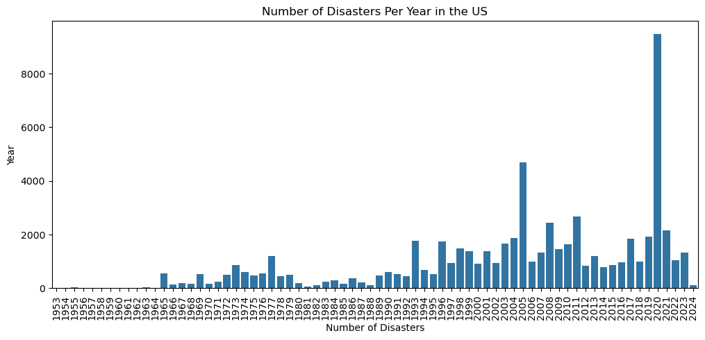

```python
plt.figure(figsize=(12,5))
g = sns.barplot(num_disasters_per_year, x='fyDeclared', y='femaDeclarationString')
g.set_xticklabels(g.get_xticklabels(), rotation=90)
g.set_title("Number of Disasters Per Year in the US")
g.set_ylabel("Year")
g.set_xlabel("Number of Disasters")
```

```python
num_disasters_per_state = df.groupby('state').count()['femaDeclarationString'].reset_index()
```

#### 3.2 Top ten states with the most disaster declarations

The top 10 states are Texas, Missouri, Kentucky, Virginia, Oaklahoma, Louisiana, Florida, Georgia, North Carolina, and Mississippi. Puerto Rico has more disaster declarations than Mississippi, but it is not a state.

```python
usa = gpd.read_file('./cb_2018_us_state_500k')
gdf = usa.merge(num_disasters_per_state, left_on='STUSPS', right_on='state')
```

```python
def makeColorColumn(gdf,variable,vmin,vmax):
    norm = mcolors.Normalize(vmin=vmin, vmax=vmax, clip=True)
    mapper = plt.cm.ScalarMappable(norm=norm, cmap=plt.cm.YlOrBr)
    gdf['value_determined_color'] = gdf[variable].apply(lambda x: mcolors.to_hex(mapper.to_rgba(x)))
    return gdf
vmin, vmax = num_disasters_per_state['femaDeclarationString'].min(), num_disasters_per_state['femaDeclarationString'].max()
variable = 'femaDeclarationString'
gdf = makeColorColumn(gdf,variable,vmin,vmax)
```

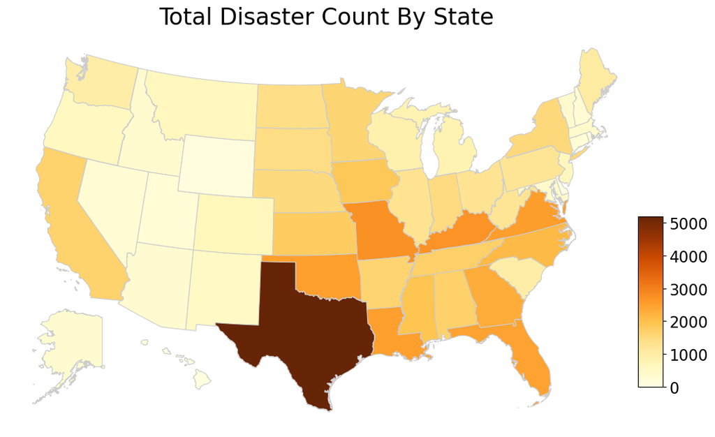

```python
visframe = gdf.to_crs({'init':'epsg:2163'})

fig, ax = plt.subplots(1, figsize=(12, 8))
ax.axis('off')
ax.set_title('Total Disaster Count By State', fontdict={'fontsize': '24', 'fontweight' : '1'})

fig = ax.get_figure()
cbax = fig.add_axes([0.89, 0.21, 0.03, 0.31])
sm = plt.cm.ScalarMappable(cmap="YlOrBr", norm=plt.Normalize(vmin=vmin, vmax=vmax))

sm._A = []
fig.colorbar(sm, cax=cbax).set_ticks(np.arange(0, 6000, 1000))
tick_font_size = 16
cbax.tick_params(labelsize=tick_font_size)

for row in visframe.itertuples():
    if row.state not in ['AK','HI', 'MP', 'GU', 'PW', 'FM', 'AS', 'PR', 'MH', 'VI']:
        vf = visframe[visframe.state==row.state]
        c = gdf[gdf.state==row.state][0:1].value_determined_color.item()
        vf.plot(color=c, linewidth=0.8, ax=ax, edgecolor='0.8')

akax = fig.add_axes([0.1, 0.17, 0.2, 0.19])
akax.axis('off')
# polygon to clip western islands
polygon = Polygon([(-170,50),(-170,72),(-140, 72),(-140,50)])
alaska_gdf = gdf[gdf.state=='AK']
alaska_gdf.clip(polygon).plot(color=gdf[gdf.state=='AK'].value_determined_color, linewidth=0.8,ax=akax, edgecolor='0.8')

hiax = fig.add_axes([.28, 0.20, 0.1, 0.1])
hiax.axis('off')
hipolygon = Polygon([(-160,0),(-160,90),(-120,90),(-120,0)])
hawaii_gdf = gdf[gdf.state=='HI']
hawaii_gdf.clip(hipolygon).plot(column=variable, color=hawaii_gdf['value_determined_color'], linewidth=0.8,ax=hiax, edgecolor='0.8')
```

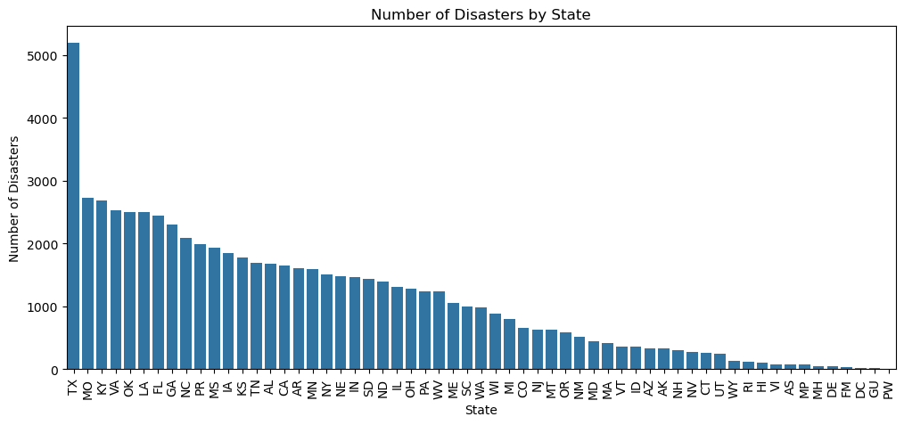

```python
plt.figure(figsize=(12,5))
g = sns.barplot(num_disasters_per_state, x='state', y='femaDeclarationString', order=num_disasters_per_state.sort_values('femaDeclarationString', ascending=False).state)
g.set_xticklabels(g.get_xticklabels(), rotation=90)
g.set_title("Number of Disasters by State")
g.set_ylabel("Number of Disasters")
g.set_xlabel("State")
```

```python
num_disasters_per_state.sort_values('femaDeclarationString', ascending=False).state[:11]
```

```
50    TX
28    MO
20    KY
52    VA
41    OK
21    LA
10    FL
12    GA
32    NC
44    PR
30    MS
Name: state, dtype: object
```

#### 3.3 Most frequent types of disasters, nationwide and for all 50 states

The most frequent types of disaster nationwide include severe storm, hurricane, and floods, followed by biological.

```python
incident_frequency = df.groupby(['incidentType']).count()['femaDeclarationString'].reset_index().sort_values('femaDeclarationString', ascending=False)
```

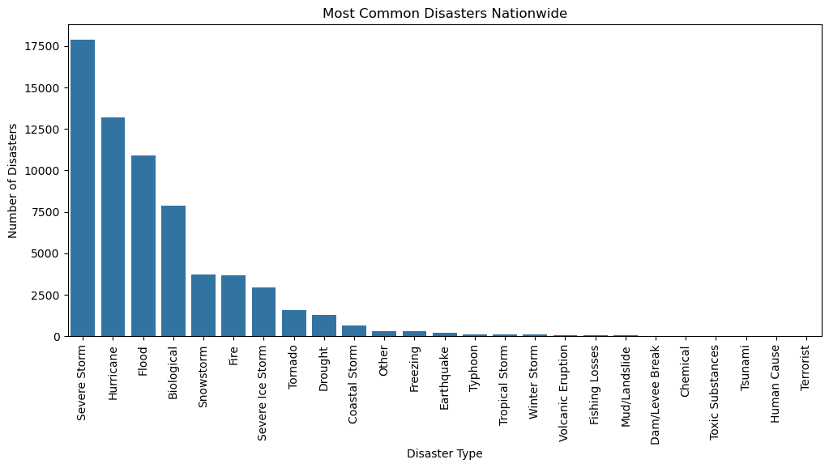

```python
plt.figure(figsize=(12,5))
g = sns.barplot(incident_frequency, x='incidentType', y='femaDeclarationString')
g.set_xticklabels(g.get_xticklabels(), rotation=90)
g.set_title("Most Common Disasters Nationwide")
g.set_ylabel("Number of Disasters")
g.set_xlabel("Disaster Type")
```

```python
incident_frequency_state = df.groupby(['state', 'incidentType']).count()['femaDeclarationString'].reset_index().sort_values('femaDeclarationString', ascending=False)
incident_frequency_state = incident_frequency_state.rename(columns={'femaDeclarationString': 'numDisasters'})
top_incidents_by_state = incident_frequency_state.groupby('state').max().reset_index()
```

```python
gdf_incident_freq = usa.merge(top_incidents_by_state, left_on='STUSPS', right_on='state')
```

```python
fig = px.choropleth(gdf_incident_freq,
                   geojson=gdf_incident_freq.geometry,
                   locations=gdf_incident_freq.index,
                   color="incidentType",
                   hover_name="state",
                   hover_data="numDisasters",
                   scope="usa")

fig.update_layout(
    title_text="Most Common Disaster by State<br>(Hover for breakdown)"
    )
fig.show()
```

[output not shown]

#### 3.4 Most frequent declaration month for disasters, nationwide and for all 50 states

The most frequent declaration month nationwide is March. However, when we look state by state, All 50 states declare mostly in September. The remaining declarations come from US Territories.

```python
df['declMonth'] = df['declarationDate'].dt.month
```

```python
common_month_nation = df.groupby('declMonth').count()['femaDeclarationString'].reset_index()
common_month_nation['declMonth'] = common_month_nation['declMonth'].map({1: 'January',
                                                                        2: 'Feburary',
                                                                        3: 'March',
                                                                        4: 'April',
                                                                        5: 'May',
                                                                        6: 'June',
                                                                        7: 'July',
                                                                        8: 'August',
                                                                        9: 'September',
                                                                        10: 'October',
                                                                        11: 'November',
                                                                        12: 'December'})
```

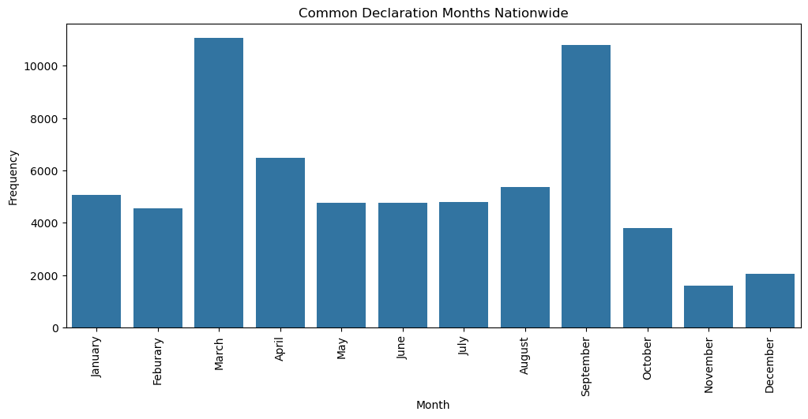

```python
plt.figure(figsize=(12,5))
g = sns.barplot(common_month_nation, x='declMonth', y='femaDeclarationString')
g.set_xticklabels(g.get_xticklabels(), rotation=90)
g.set_title("Common Declaration Months Nationwide")
g.set_ylabel("Frequency")
g.set_xlabel("Month")
```

```python
common_month_state = df.groupby(['state', 'declMonth' ]).count()['femaDeclarationString'].reset_index().sort_values('femaDeclarationString', ascending=False)
common_month_state = common_month_state.rename(columns={'femaDeclarationString': 'freq'})
common_month_state['declMonth'] = common_month_state['declMonth'].map({1: 'January',
                                                                        2: 'Feburary',
                                                                        3: 'March',
                                                                        4: 'April',
                                                                        5: 'May',
                                                                        6: 'June',
                                                                        7: 'July',
                                                                        8: 'August',
                                                                        9: 'September',
                                                                        10: 'October',
                                                                        11: 'November',
                                                                        12: 'December'})
top_months_by_state = common_month_state.groupby('state').max().reset_index()
```

```python
gdf_month_freq = usa.merge(top_months_by_state, left_on='STUSPS', right_on='state')
```

```python
fig = px.choropleth(gdf_month_freq,
                   geojson=gdf_month_freq.geometry,
                   locations=gdf_month_freq.index,
                   color="declMonth",
                   hover_name="state",
                   hover_data="freq",
                   scope="usa")

fig.update_layout(
    title_text="Most Common Declaration Months by State<br>(Hover for breakdown)"
    )
fig.show()
```

[output not shown]

#### 3.5 Disasters “open” the longest

Disasters open the longest include volcanic eruptions, human causes (which include explosions and undocumented aliens), and tsunamis.

```python
avg_closeout_times = df.groupby('incidentType')['closeoutTime'].mean().reset_index().sort_values(by='closeoutTime', ascending=False)
avg_closeout_times['years'] = avg_closeout_times.closeoutTime.dt.days/365.2425
```

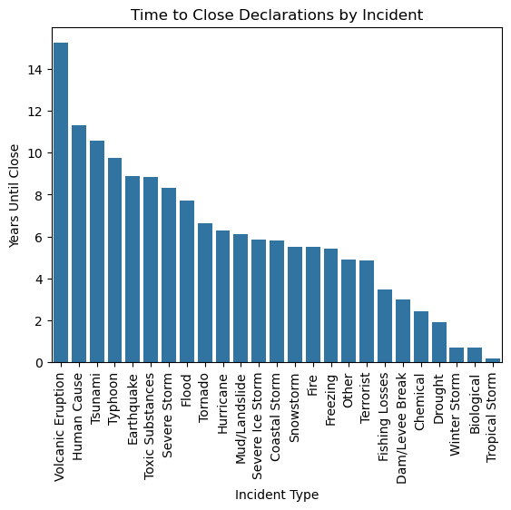

```python
g = sns.barplot(avg_closeout_times, x='incidentType', y='years')
g.set_xticklabels(g.get_xticklabels(), rotation=90)
g.set_title("Time to Close Declarations by Incident")
g.set_ylabel("Years Until Close")
g.set_xlabel("Incident Type")
```

```python
df.query("incidentType == 'Human Cause'").declarationTitle
```

```
24717    EXPLOSION AT FEDERAL COURTHOUSE IN OKLAHOMA CITY
25722                                 UNDOCUMENTED ALIENS
25723                                 UNDOCUMENTED ALIENS
25724                                 UNDOCUMENTED ALIENS
25725                                 UNDOCUMENTED ALIENS
45882    EXPLOSION AT FEDERAL COURTHOUSE IN OKLAHOMA CITY
47338                     EXPLOSION AT WORLD TRADE CENTER
Name: declarationTitle, dtype: object
```

This heatmap represents the frequency of disasters declared at each month for each incident. Earlier, we saw most declarations are made in September, and here we see that is mostly due to hurricanes. March was also a common month for declarations, and it is due to Biological, or Covid-19.

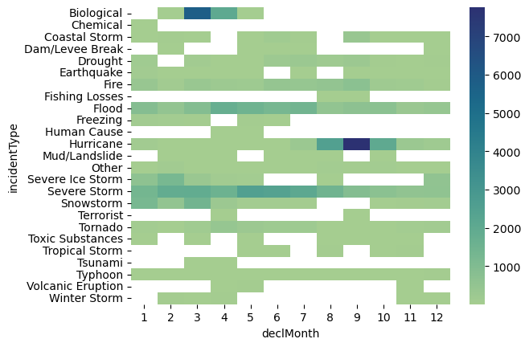

```python
disaster_type_month_freq = df.groupby(['incidentType', 'declMonth']).count()['femaDeclarationString'].reset_index().pivot(
    index="incidentType", columns="declMonth", values="femaDeclarationString"
    )
sns.heatmap(disaster_type_month_freq, annot=False, cmap="crest")
```

### 4 Statistical Analysis – Calculate summary statistics and/or identify correlations that help further tell the story of insights you are seeing from your data exploration.

There appears to be correlation between how long an incident takes and when a declaration is closed. The correlation is negative, which means the longer the incident, the shorter time it takes to close.

```python
average_durations_incident = df.groupby(['incidentType'])['incidentDuration'].mean().reset_index()
average_durations_incident['incident_days'] = average_durations_incident.incidentDuration.dt.days
avg_closeout_times['closeout_days'] = avg_closeout_times.closeoutTime.dt.days
```

```python
avg_closeout_times.merge(average_durations_incident, on='incidentType')[['incident_days','closeout_days' ]].corr()
```

|  | incident_days | closeout_days |
| --- | --- | --- |
| incident_days | 1.000000 | -0.258236 |
| closeout_days | -0.258236 | 1.000000 |

Volcanic eruptions are not common, but they take very long to close out. I calculated the correlation between years to close and the frequency of incidents to see if there is any relationship, but with a correlation of 0.035, there is a weak positive correlation.

```python
closetime_incident_counts = avg_closeout_times.merge(incident_frequency, on='incidentType')
closetime_incident_counts = closetime_incident_counts.rename(columns={'femaDeclarationString': 'freq'})
closetime_incident_counts[['years', 'freq']].corr()
```

|  | years | freq |
| --- | --- | --- |
| years | 1.000000 | 0.034638 |
| freq | 0.034638 | 1.000000 |

I noticed there are negative durations after calculating summary statistics for this dataset. This indicates that the incident end dates, filing dates, and closing dates, are recorded to be sooner than when the incident started. This could be due to input errors when creating this dataset, due to transcription, typos, or otherwise.

```python
df.describe().drop(['fipsStateCode', 'fipsCountyCode', 'placeCode'], axis=1)
```

|  | disasterNumber | fyDeclared | declarationRequestNumber | incidentDuration | IAFilingTime | closeoutTime | declMonth |
| --- | --- | --- | --- | --- | --- | --- | --- |
| count | 65037.000000 | 65037.000000 | 65037.000000 | 64567 | 18034 | 50713 | 65037.000000 |
| mean | 2605.940296 | 2004.613159 | 34852.998847 | 166 days 20:22:19.706041788 | 531 days 13:14:49.120550072 | 2379 days 08:13:01.432768672 | 5.826022 |
| std | 1416.428094 | 14.848889 | 34730.439435 | 389 days 00:14:18.586818376 | 809 days 23:49:14.548688904 | 1636 days 16:26:26.342762640 | 3.099619 |
| min | 1.000000 | 1953.000000 | 3.000000 | -7 days +00:00:00 | -305 days +00:00:00 | -1341 days +00:00:00 | 1.000000 |
| 25% | 1331.000000 | 1997.000000 | 8172.000000 | 3 days 00:00:00 | 61 days 00:00:00 | 981 days 00:00:00 | 3.000000 |
| 50% | 3100.000000 | 2007.000000 | 20036.000000 | 13 days 00:00:00 | 90 days 00:00:00 | 2277 days 00:00:00 | 6.000000 |
| 75% | 3567.000000 | 2018.000000 | 73097.000000 | 42 days 00:00:00 | 199 days 00:00:00 | 3470 days 00:00:00 | 9.000000 |
| max | 5489.000000 | 2024.000000 | 99159.000000 | 5117 days 00:00:00 | 2020 days 00:00:00 | 12107 days 00:00:00 | 12.000000 |

```python
df.iloc[df.closeoutTime.idxmin()]
```

```
femaDeclarationString                                     DR-1711-KS
disasterNumber                                                  1711
state                                                             KS
declarationType                                                   DR
declarationDate                            2007-07-02 00:00:00+00:00
fyDeclared                                                      2007
incidentType                                            Severe Storm
declarationTitle                          SEVERE STORMS AND FLOODING
ihProgramDeclared                                               True
iaProgramDeclared                                               True
paProgramDeclared                                               True
hmProgramDeclared                                               True
incidentBeginDate                          2007-06-26 00:00:00+00:00
incidentEndDate                            2007-07-25 00:00:00+00:00
disasterCloseoutDate                       2003-10-30 00:00:00+00:00
tribalRequest                                                  False
fipsStateCode                                                     20
fipsCountyCode                                                     1
placeCode                                                      99001
designatedArea                                        Allen (County)
declarationRequestNumber                                        7856
lastIAFilingDate                           2007-09-04 00:00:00+00:00
lastRefresh                         2023-05-22 03:41:22.800000+00:00
hash                        6000903362c635d73946f5396aca10f94daea9b2
id                              65781072-9a21-47a3-b05a-29fe4af36533
incidentDuration                                    29 days 00:00:00
IAFilingTime                                        64 days 00:00:00
closeoutTime                                    -1341 days +00:00:00
declMonth                                                          7
Name: 33278, dtype: object
```

#### 5 Predictive Modeling – Which types of predictive modeling techniques are suitable to apply to this data set? Which are not? What additional data sets may be helpful in building a model that aligns to the goals in FEMA’s Strategic Plan? Be prepared to discuss and explain your thinking during the interview. Bonus points for implementing a predictive model as part of the pre-work assignment.

We saw earlier that the `disasterCloseoutDate` were far from the initial declaration date. In addition, the time to close were on the scale of years, and without machine learning, the only way we can get the date is to wait until the transactions are done. So it might be useful to use the data to predict the close date. A linear model is a typical start. We have time variables and categorical variables mostly in this data set. The advantage of this method is that it is interpretable: we can see which variables contribute best when predicting the date by looking at the output. It is also easy to implement. However, since we have many categorical variables in this data set, we would need to encode them and increase the dimensionality of the data set in doing so, which could end up diluting our data. We would also need to be careful about our assumptions as well, such as errors being normally distributed and the linearity of the features. Otherwise, this dataset may not be suited for supervised learning, as there is not a target variable we are interested in, such as money spent towards a disaster. In this context, supervised learning models such as regression may not apply to this data set, but unsupervised models such as k-means clustering are. K-means can help us see which rows of data are more closely related to each other and can also help find anomalies in the data.

The 3 overall goals for FEMA's Strategic Plan are

1. Instill Equity as a Foundation of Emergency Management
2. Lead Whole of Community in Climate Resilience
3. Promote and Sustain a Ready FEMA and Prepared Nation

We have a data set that gives us the base information about a disaster: type of disaster, date when it happened/declared, where it happened, and any programs that aid in the disaster. To instill equity, data on demographics and socioeconomic factors would be helpful. Addition of this data can help us understand who the disasters are impacting. This can help us see if people of low-income are being impacted, middle-class families, or high earners, and would help FEMA allocate resources to those who need it more, such as underserved communities. The information can also track how equitable FEMA is in their assistance by checking who is receiving the assistance. This kind of data can be obtained from the census and the Bureau of Labor Statistics for example.

Fema's plan to tackle climate change is to increase understanding of climate change, investing in communities to improve infrastructure, and leveraging data to understand risk to make informed decisions. Data from the Global Change Research Program can help with this, identifying communities which need resources to strengthen their infrastructure against climate change. It also provides data on losses due to disasters and pollution. This data can help with understanding how disasters from climate change impacts communities compared to disasters in the past. As such, we would have information on the magnitude of the impacts as well, and reevaluate risks.

Finally, these data will help with the third goal by informing us where resources are needed most. With OpenFEMA, climate change data, and socioeconomic data, we can see who and where people need assistance, as well as why they need the assistance. This gives us the data we need to support workforce decisions such as training and hiring. It also allows us to anticipate which disasters are likely to have an impact in the future.